# demo

Tests for machine learning(0083-刘培爱)

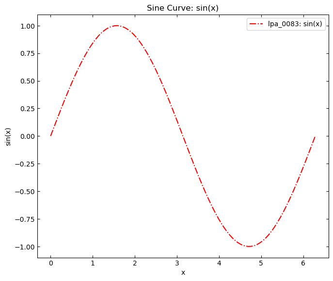

```python
import numpy as np
import matplotlib.pyplot as plt
x = np.linspace(0,2*np.pi,100)
y = np.sin(x)

fig = plt.figure(figsize=(7.75, 6.5))
plt.rcParams['mathtext.fontset'] = 'cm'
plt.rcParams['xtick.direction'] = 'in'
plt.rcParams['ytick.direction'] = 'in'
plt.rcParams['xtick.top'] = True
plt.rcParams['ytick.right'] = True


plt.plot(x,y, 'r-.', label='lpa_0083: sin(x)')
plt.title('Sine Curve: sin(x)')
plt.legend()
plt.xlabel('x')
plt.ylabel('sin(x)')
plt.savefig('./data_fig/fig1_lpa_0083.png')
plt.show()
```

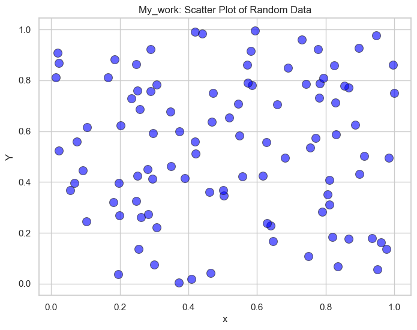

```python
import pandas as pd
import seaborn as sns

rng = pd.DataFrame({
    'x': np.random.rand(100),
    'Y': np.random.rand(100)
})
sns.set(style='whitegrid')
plt.figure(figsize=(8, 6))
sns.scatterplot(data=rng, x='x', y='Y', color='blue',
                s=100, alpha=0.6, edgecolor='k')
plt.title('My_work: Scatter Plot of Random Data')
plt.xlabel('x')
plt.ylabel('Y')

plt.savefig('./data_fig/fig2_scatter.png', dpi=300, bbox_inches='tight')
plt.show()
plt.close()
```

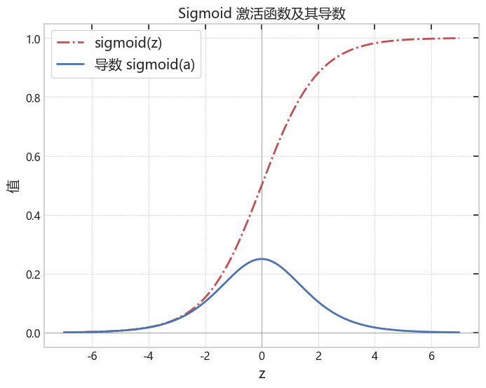

```python
import numpy as np
import matplotlib.pyplot as plt

import matplotlib
matplotlib.rcParams['font.sans-serif'] = ['Microsoft YaHei', 'SimHei', 'DejaVu Sans']
matplotlib.rcParams['axes.unicode_minus'] = False

def sigmoid(z):
    return 1/(1+np.exp(-np.clip(z,-500,500)))

def sigmoid_derivative(a):
    return a * (1 - a)

z = np.linspace(-7,7,200)
a = sigmoid(z)
da=sigmoid_derivative(a)

plt.figure(figsize=(8, 6))
plt.rcParams['mathtext.fontset'] = 'cm'
plt.rcParams['xtick.direction'] = 'in'
plt.rcParams['ytick.direction'] = 'in'
plt.rcParams['xtick.top'] = True
plt.rcParams['ytick.right'] = True


plt.plot(z,a, 'r-.', label='sigmoid(z)',linewidth=2)
plt.plot(z,da, 'b-', label='导数 sigmoid(a)',linewidth=2)
plt.title('Sigmoid 激活函数及其导数', fontsize=14)
plt.xlabel('z', fontsize=14)
plt.ylabel('值', fontsize=14)
plt.axhline(0, color='gray', lw=0.5)
plt.axvline(0, color='gray', lw=0.5)
plt.grid(False, which='both', linestyle='--', linewidth=0.5)
plt.legend(fontsize=14)
plt.savefig('./data_fig/fig3_sigmoid.png', dpi=300, bbox_inches='tight')
plt.show()
```

```python
import random
import math

class TwoLayerNN:
    def __init__(self, input_size, hidden_size, output_size, learning_rate=0.1):
        self.input_size = input_size
        self.hidden_size = hidden_size
        self.output_size = output_size
        self.learning_rate = learning_rate

        self.W1 = [[random.uniform(-1.0, 1.0) for _ in range(hidden_size)] for _ in range(input_size)]
        self.b1 = [0.0 for _ in range(hidden_size)]
        self.W2 = [[random.uniform(-1.0, 1.0) for _ in range(output_size)] for _ in range(hidden_size)]
        self.b2 = [0.0 for _ in range(output_size)]

    @staticmethod
    def relu(x):
        return x if x > 0 else 0.0

    @staticmethod
    def relu_derivative(x):
        return 1.0 if x > 0 else 0.0

    @staticmethod
    def softmax(logits):
        max_logit = max(logits)
        exps = [math.exp(x - max_logit) for x in logits]
        total = sum(exps)
        return [e / total for e in exps]

    @staticmethod
    def dot_product(vec, mat_col):
        return sum(v * m for v, m in zip(vec, mat_col))

    def forward(self, x):
        self.z1 = [sum(x[i] * self.W1[i][j] for i in range(self.input_size)) + self.b1[j] for j in range(self.hidden_size)]
        self.a1 = [self.relu(z) for z in self.z1]
        self.z2 = [sum(self.a1[i] * self.W2[i][j] for i in range(self.hidden_size)) + self.b2[j] for j in range(self.output_size)]
        self.a2 = self.softmax(self.z2)
        return self.a2

    @staticmethod
    def cross_entropy_loss(predicted, target):
        return -sum(target[i] * math.log(predicted[i] + 1e-15) for i in range(len(target)))

    def backward(self, x, target):
        d_z2 = [self.a2[i] - target[i] for i in range(self.output_size)]

        dW2 = [[self.a1[h] * d_z2[o] for o in range(self.output_size)] for h in range(self.hidden_size)]
        db2 = d_z2[:]

        d_a1 = [sum(self.W2[h][o] * d_z2[o] for o in range(self.output_size)) for h in range(self.hidden_size)]
        d_z1 = [d_a1[h] * self.relu_derivative(self.z1[h]) for h in range(self.hidden_size)]

        dW1 = [[x[i] * d_z1[h] for h in range(self.hidden_size)] for i in range(self.input_size)]
        db1 = d_z1[:]

        for i in range(self.input_size):
            for h in range(self.hidden_size):
                self.W1[i][h] -= self.learning_rate * dW1[i][h]

        for h in range(self.hidden_size):
            self.b1[h] -= self.learning_rate * db1[h]
            for o in range(self.output_size):
                self.W2[h][o] -= self.learning_rate * dW2[h][o]

        for o in range(self.output_size):
            self.b2[o] -= self.learning_rate * db2[o]

    def predict(self, x):
        output = self.forward(x)
        return max(range(len(output)), key=lambda i: output[i])

    def train(self, data, labels, epochs=1000):
        for epoch in range(epochs):
            total_loss = 0.0
            for x, target in zip(data, labels):
                self.forward(x)
                total_loss += self.cross_entropy_loss(self.a2, target)
                self.backward(x, target)
            if (epoch + 1) % (epochs // 10 or 1) == 0:
                print(f"Epoch {epoch + 1}/{epochs} loss={total_loss / len(data):.6f}")


def one_hot(index, size):
    vec = [0.0] * size
    vec[index] = 1.0
    return vec


if __name__ == "__main__":
    data = [
        [0.0, 0.0],
        [0.0, 1.0],
        [1.0, 0.0],
        [1.0, 1.0],
    ]
    labels = [one_hot(0, 2), one_hot(1, 2), one_hot(1, 2), one_hot(0, 2)]

    model = TwoLayerNN(input_size=2, hidden_size=4, output_size=2, learning_rate=0.1)
    model.train(data, labels, epochs=2000)

    for x, y in zip(data, labels):
        prediction = model.predict(x)
        print(f"input={x}, predicted={prediction}, target={y.index(1.0)}")
```

```
input=[0.0, 0.0], predicted=0, target=0
input=[0.0, 1.0], predicted=1, target=1
input=[1.0, 0.0], predicted=1, target=1
input=[1.0, 1.0], predicted=0, target=0
```

```
[[-3.        ]
 [-2.96984925]
 [-2.93969849]
 [-2.90954774]
 [-2.87939698]]
[[-34.75492877]
 [-34.91429671]
 [-32.95400337]
 [-30.87128074]
 [-32.74891614]]
```

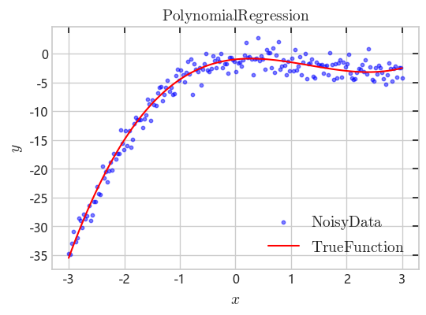

```python
import numpy as np
import matplotlib.pyplot as plt

def true_function(x):
    return 0.5 * x**3 - 2*x**2 + x - 1

x_data = np.linspace(-3, 3, 200).reshape(-1, 1)

np.random.seed(42)
noise = np.random.normal(0, 1.5, size=x_data.shape)
y_data = true_function(x_data) + noise
print(x_data[:5])
print(y_data[:5])

plt.figure(figsize=(6, 4))
plt.rcParams['mathtext.fontset'] = 'cm'
plt.rcParams['xtick.direction'] = 'in'
plt.rcParams['ytick.direction'] = 'in'
plt.rcParams['xtick.top'] = True
plt.rcParams['ytick.right'] = True

plt.scatter(x_data, y_data, s=10, color='blue', alpha=0.5, label='$\mathrm{Noisy Data}$')
x_true = np.linspace(-3, 3, 100).reshape(-1, 1)
y_true = true_function(x_true)
plt.plot(x_true, y_true, color='red', label='$\mathrm{True Function}$')
plt.xlabel('$x$', fontsize=14)
plt.ylabel('$y$', fontsize=14)
plt.title('$\mathrm{Polynomial Regression}$', fontsize=14)
plt.legend(loc='lower right', frameon=False, fontsize=14)
plt.savefig('./data_fig/fig4_polynomial_regression.png', dpi=300, bbox_inches='tight')
plt.show()
```

机器学习：激活函数定义

```python
def sigmoid(z):
    return 1/(1+np.exp(-np.clip(z,-500,500)))

def sigmoid_derivative(a):
    return a * (1 - a)

z = np.linspace(-7,7,200)
a = sigmoid(z)
da=sigmoid_derivative(a)
```

机器学习：全局变量定义

```python
##==============   超参数  ==========  #####

INPUT_SIZE = 1
HIDDEN_SIZE = 10
OUTPUT_SIZE = 1
LEARNING_RATE = 0.01
EPOCHS = 5000
```

机器学习：网络参数初始化

```python
def initialize_parameters(input_size, hidden_size, output_size):
    np.random.seed(1)
    parameters = {
        'W1': np.random.randn(input_size, hidden_size)*0.01,
        'b1': np.zeros((hidden_size,1)),
        'W2': np.random.randn(hidden_size, output_size)*0.01,
        'b2': np.zeros((output_size,1))
    }
    return parameters

params = initialize_parameters(INPUT_SIZE, HIDDEN_SIZE, OUTPUT_SIZE)

##  print parameters
print("W1 shape:", params['W1'].shape)
print(params['W1'])
print("b1 shape:", params['b1'].shape)
print(params['b1'])
print("W2 shape:", params['W2'].shape)
print(params['W2'])
print("b2 shape:", params['b2'].shape)
print(params['b2'])
#print(params)
```

```
W1 shape: (1, 10)
[[ 0.01624345 -0.00611756 -0.00528172 -0.01072969  0.00865408 -0.02301539
   0.01744812 -0.00761207  0.00319039 -0.0024937 ]]
b1 shape: (10, 1)
[[0.]
 [0.]
 [0.]
 [0.]
 [0.]
 [0.]
 [0.]
 [0.]
 [0.]
 [0.]]
W2 shape: (10, 1)
[[ 0.01462108]
 [-0.02060141]
 [-0.00322417]
 [-0.00384054]
 [ 0.01133769]
 [-0.01099891]
 [-0.00172428]
 [-0.00877858]
 [ 0.00042214]
 [ 0.00582815]]
b2 shape: (1, 1)
[[0.]]
```

机器学习：实现前向传播

Z1是如何实现的

```python
def forward_propagation(X, parameters):
    W1, b1 = parameters['W1'], parameters['b1']
    W2, b2 = parameters['W2'], parameters['b2']

    Z1 = np.dot(X, W1) + b1.T
    A1 = sigmoid(Z1)
    Z2 = np.dot(A1, W2) + b2.T
    A2 = Z2
    cache = {
        'X': X,
        'Z1': Z1,
        'A1': A1,
        'Z2': Z2,
        'A2': A2
    }
    return A2, cache

a2, _ = forward_propagation(x_data, params)
print("Output of forward propagation (A2):", a2)
```

```
Output of forward propagation (A2): [[-0.00907673]
 [-0.00907073]
 [-0.00906473]
 [-0.00905873]
 [-0.00905273]
 [-0.00904673]
 [-0.00904073]
 [-0.00903473]
 [-0.00902873]
 [-0.00902272]
 [-0.00901672]
 [-0.00901072]
 [-0.00900472]
 [-0.00899872]
 [-0.00899272]
 [-0.00898671]
 [-0.00898071]
 [-0.00897471]
 [-0.00896871]
 [-0.00896271]
 [-0.0089567 ]
 [-0.0089507 ]
 [-0.0089447 ]
 [-0.0089387 ]
 [-0.0089327 ]
 [-0.00892669]
 [-0.00892069]
 [-0.00891469]
 [-0.00890869]
 [-0.00890268]
 [-0.00889668]
 [-0.00889068]
 [-0.00888468]
 [-0.00887867]
 [-0.00887267]
 [-0.00886667]
 [-0.00886066]
 [-0.00885466]
 [-0.00884866]
 [-0.00884266]
```

[output cut: 145 more lines]

```
 [-0.00796612]
 [-0.00796012]
 [-0.00795412]
 [-0.00794812]
 [-0.00794212]
 [-0.00793611]
 [-0.00793011]
 [-0.00792411]
 [-0.00791811]
 [-0.00791211]
 [-0.00790611]
 [-0.00790011]
 [-0.00789411]
 [-0.0078881 ]
 [-0.0078821 ]]
```

机器学习：损失函数

```python
def compute_loss(y_pred, y_true):
    m = y_true.shape[0]
    loss = (1/m) * np.sum((y_pred - y_true)**2)
    return loss

a2, cache = forward_propagation(x_data, params)
loss = compute_loss(a2, y_data)
print("loss:", loss)
```

```
loss: 129.43138800486602
```

机器学习：反向传播（链式法则），高效计算受损失函数对每个参数（数值积分单独求导）的梯度，从而利用梯度下降更新参数

计算复杂度与参数量成正比

链式法则：神经网络是一个复合函数：隐藏层，输出层，中间变量

需要更新四个参数：假设损失函数是均方误差（MSE），参数梯度

```python
def backward_propagation(parameters, cache, X, y_true):
    m = X.shape[0]
    W2 = parameters['W2']
    A1 = cache['A1']
    A2 = cache['A2']
    Z1 = cache['Z1']

    dZ2 = (2/m) * (A2 - y_true)
    dW2 = np.dot(A1.T, dZ2) / m
    db2 = np.sum(dZ2, axis=0, keepdims=True) / m

    dA1 = np.dot(dZ2, W2.T)
    dZ1 = dA1 * sigmoid_derivative(A1)
    dW1 = np.dot(X.T, dZ1) / m
    db1 = np.sum(dZ1, axis=0, keepdims=True) / m

    grads = {
        'dW1': dW1,
        'db1': db1,
        'dW2': dW2,
        'db2': db2
    }
    return grads

grads = backward_propagation(params, cache, x_data, y_data)
print("Gradients:")
for key in grads:
    print(f"{key}: {grads[key].shape}")
```

```
Gradients:
dW1: (1, 10)
db1: (1, 10)
dW2: (10, 1)
db2: (1, 1)
```

机器学习：参数更新函数

```python
def update_parameters(parameters, grads, learning_rate):
    parameters['W1'] -= learning_rate * grads['dW1']
    parameters['b1'] -= learning_rate * grads['db1'].T
    parameters['W2'] -= learning_rate * grads['dW2']
    parameters['b2'] -= learning_rate * grads['db2'].T
    return parameters
```

训练循环与中间变量记录

```python
parms = initialize_parameters(INPUT_SIZE, HIDDEN_SIZE, OUTPUT_SIZE)
loss_history = []
snapshot = []
x_test = np.linspace(-3, 3, 100).reshape(-1, 1)

for epoch in range(1, EPOCHS + 1):
    #前向传播
    y_pred, cache = forward_propagation(x_data, parms)
    #计算损失
    loss = compute_loss(y_pred, y_data)
    loss_history.append(loss)

    #反向传播
    grads = backward_propagation(parms, cache, x_data, y_data)
    #更新参数
    parms = update_parameters(parms, grads, LEARNING_RATE)

    if epoch % 10 == 0 or epoch == 1 or epoch == EPOCHS:
        y_curve, _ = forward_propagation(x_test, parms)
        # store the predicted curve (flattened) instead of parameters
        try:
            y_curve_flat = y_curve.ravel()
        except Exception:
            y_curve_flat = np.array(y_curve).reshape(-1)
        snapshot.append((epoch, y_curve_flat))
        print(f"Epoch {epoch}/{EPOCHS}, Loss: {loss:.4f}")
```

可视化1-训练损失曲线

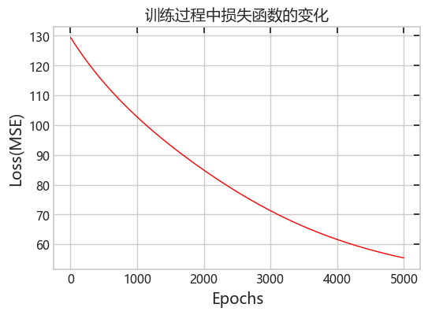

```python
plt.figure(figsize=(6, 4))
plt.rcParams['mathtext.fontset'] = 'cm'
plt.rcParams['xtick.direction'] = 'in'
plt.rcParams['ytick.direction'] = 'in'
plt.rcParams['xtick.top'] = True
plt.rcParams['ytick.right'] = True


plt.plot(range(1, EPOCHS + 1), loss_history, color='red',linewidth=1)
plt.xlabel('Epochs', fontsize=14)
plt.ylabel('Loss(MSE)', fontsize=14)
plt.title('训练过程中损失函数的变化', fontsize=14)
plt.savefig('./data_fig/fig5_loss_curve.png', dpi=300, bbox_inches='tight')
plt.show()
```

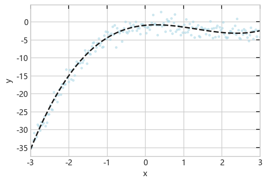

```python
plt.figure(figsize=(6, 4))
plt.scatter (x_data, y_data, s=8, color='lightblue', alpha=0.5, label='训练数据')
x_curve = np.linspace(-3, 3, 100).reshape(-1, 1)
plt.plot(x_curve, true_function(x_curve), 'k--',linewidth=2, label='真实函数')
colors = plt.cm.viridis(np.linspace(0.2, 0.9, len(snapshot)))

plt.xlabel('x')
plt.ylabel('y')
plt.xlim(-3., 3.)
plt.savefig('./data_fig/fig6_function.png')
```

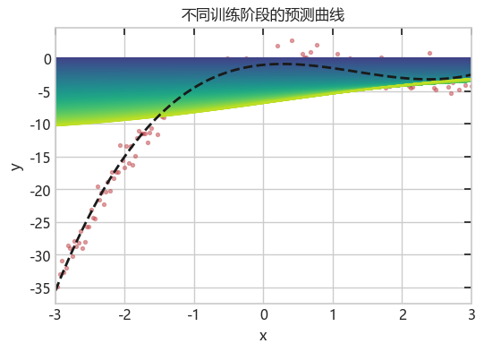

```python
plt.figure(figsize=(6, 4))

colors = plt.cm.viridis(np.linspace(0.2, 0.9, len(snapshot)))
for (epoch, y_curve_pred), color in zip(snapshot, colors):
    plt.plot(x_curve, y_curve_pred, color=color, linewidth=1.5, label=f'Epoch {epoch}')

plt.scatter(x_data, y_data, s=8,color='r',alpha=0.5,label='训练数据')
x_curve = np.linspace(-3, 3, 100).reshape(-1, 1)
plt.plot(x_curve, true_function(x_curve), 'k--', linewidth=2,label='真实函数')

plt.xlabel('x')
plt.ylabel('y')
plt.xlim(-3., 3.)
plt.title('不同训练阶段的预测曲线')
#plt.legend(loc='lower right')
#plt.grid(True)
plt.savefig('./data_fig/fig7_mid-curve.png', dpi=300, bbox_inches='tight')
```

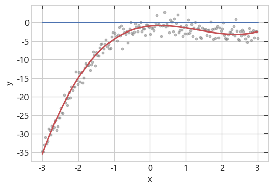

```python
y_final_pred, _= forward_propagation(x_test, params)
plt.figure(figsize=(6, 4))
plt.scatter(x_data, y_data, s=10, color='gray', alpha=0.5, label='训练数据')
plt.plot(x_curve, true_function(x_curve), 'r-', linewidth=2, label='真实函数')
plt.plot(x_curve, y_final_pred, 'b-', linewidth=2, label='神经网络预测')
plt.xlabel('x')
plt.ylabel('y')
```

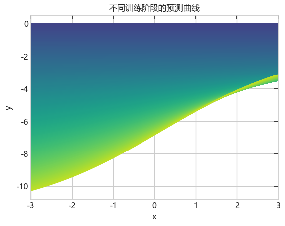

```python
colors = plt.cm.viridis(np.linspace(0.2, 0.9, len(snapshot)))
for (epoch, y_curve_pred), color in zip(snapshot, colors):
    plt.plot(x_curve, y_curve_pred, color=color, linewidth=1.5, label=f'Epoch {epoch}')
plt.xlabel('x')
plt.ylabel('y')
plt.xlim(-3., 3.)
plt.title('不同训练阶段的预测曲线')
#plt.legend(loc='lower right')
#plt.grid(True)
plt.savefig('./data_fig/fig7_mid-curve.png', dpi=300, bbox_inches='tight')
```

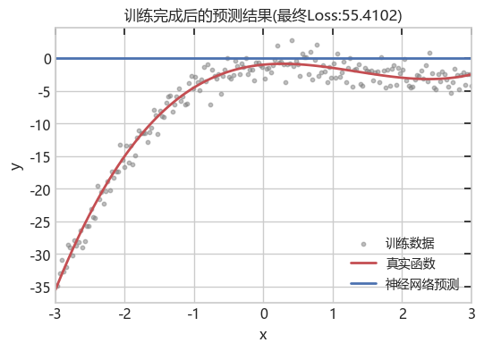

```python
y_final_pred, _ = forward_propagation(x_test, params)
plt.figure(figsize=(6, 4))
plt.scatter(x_data, y_data, s=10, color='gray', alpha=0.5, label='训练数据')
plt.plot(x_curve, true_function(x_curve), 'r-', linewidth=2, label='真实函数')
plt.plot(x_curve, y_final_pred, 'b-', linewidth=2, label='神经网络预测')
plt.xlabel('x')
plt.ylabel('y')
plt.xlim(-3., 3.)
plt.title(f'训练完成后的预测结果(最终Loss:{loss_history[-1]:.4f})')
plt.legend(loc='lower right', frameon=False, fontsize=10)
#plt.grid(True)
plt.savefig('./data_fig/fig8_final.png', dpi=300, bbox_inches='tight')
```

[output not shown]

```
[[-3.        ]
 [-2.96984925]
 [-2.93969849]
 [-2.90954774]
 [-2.87939698]]
[[-34.75492877]
 [-34.91429671]
 [-32.95400337]
 [-30.87128074]
 [-32.74891614]]
W1 shape: (1, 10)
[[ 0.01624345 -0.00611756 -0.00528172 -0.01072969  0.00865408 -0.02301539
   0.01744812 -0.00761207  0.00319039 -0.0024937 ]]
b1 shape: (10, 1)
[[0.]
 [0.]
 [0.]
 [0.]
 [0.]
 [0.]
 [0.]
 [0.]
 [0.]
 [0.]]
W2 shape: (10, 1)
[[ 0.01462108]
 [-0.02060141]
 [-0.00322417]
 [-0.00384054]
 [ 0.01133769]
 [-0.01099891]
 [-0.00172428]
 [-0.00877858]
 [ 0.00042214]
 [ 0.00582815]]
b2 shape: (1, 1)
[[0.]]
Output of forward propagation (A2): [[-0.00907673]
 [-0.00907073]
 [-0.00906473]
```

[output cut: 183 more lines]

```
 [-0.00796012]
 [-0.00795412]
 [-0.00794812]
 [-0.00794212]
 [-0.00793611]
 [-0.00793011]
 [-0.00792411]
 [-0.00791811]
 [-0.00791211]
 [-0.00790611]
 [-0.00790011]
 [-0.00789411]
 [-0.0078881 ]
 [-0.0078821 ]]
Loss: 129.43138800486602
```

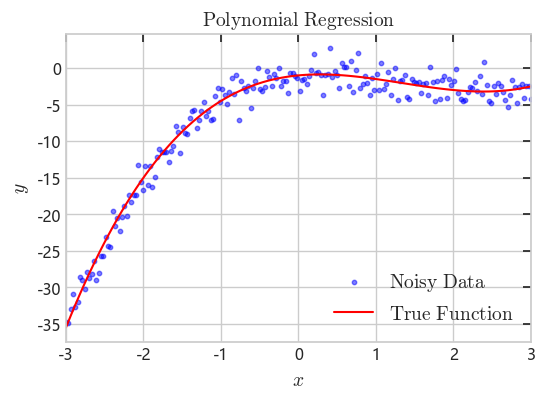

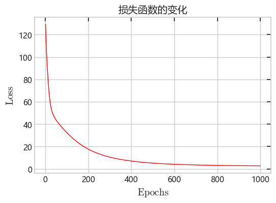

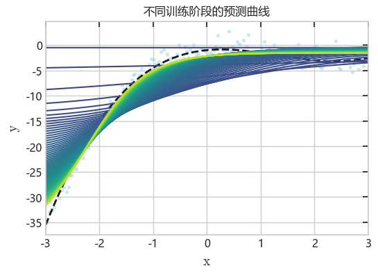

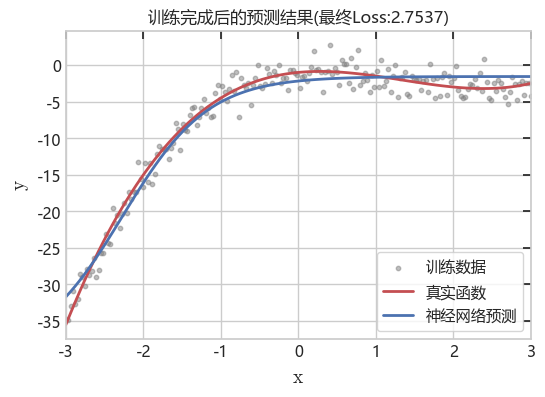

```python
import numpy as np
import matplotlib.pyplot as plt

def true_function(x):
    return 0.5 * x**3 - 2*x**2 + x - 1

x_data = np.linspace(-3, 3, 200).reshape(-1, 1)

np.random.seed(42)
noise = np.random.normal(0, 1.5, size=x_data.shape)
y_data = true_function(x_data) + noise
print(x_data[:5])
print(y_data[:5])

plt.figure(figsize=(6, 4))
plt.rcParams['mathtext.fontset'] = 'cm'
plt.rcParams['xtick.direction'] = 'in'
plt.rcParams['ytick.direction'] = 'in'
plt.rcParams['xtick.top'] = True
plt.rcParams['ytick.right'] = True

plt.scatter(x_data, y_data, s=10, color='blue', alpha=0.5, label='$\mathrm{Noisy\ Data}$')
x_true = np.linspace(-3, 3, 100).reshape(-1, 1)
y_true = true_function(x_true)
plt.plot(x_true, y_true, color='red', label='$\mathrm{True\ Function}$')
plt.xlabel('$x$', fontsize=14)
plt.ylabel('$y$', fontsize=14)
plt.xlim(-3., 3.)
plt.title('$\mathrm{Polynomial\ Regression}$', fontsize=14)
plt.legend(loc='lower right', frameon=False, fontsize=14)
plt.savefig('./data_fig/fig4_polynomial_regression.png', dpi=300, bbox_inches='tight')
#plt.show()


def sigmoid(z):
    return 1/(1+np.exp(-np.clip(z,-500,500)))

def sigmoid_derivative(a):
    return a * (1 - a)

z = np.linspace(-7,7,200)
a = sigmoid(z)
da=sigmoid_derivative(a)



INPUT_SIZE = 1
HIDDEN_SIZE = 10
OUTPUT_SIZE = 1
LEARNING_RATE = 0.01
EPOCHS = 1000



def initialize_parameters(input_size, hidden_size, output_size):
    np.random.seed(1)
    parameters = {
        'W1': np.random.randn(input_size, hidden_size)*0.01,
        'b1': np.zeros((hidden_size,1)),
        'W2': np.random.randn(hidden_size, output_size)*0.01,
        'b2': np.zeros((output_size,1))
    }
    return parameters

params = initialize_parameters(INPUT_SIZE, HIDDEN_SIZE, OUTPUT_SIZE)

##  print parameters
print("W1 shape:", params['W1'].shape)
print(params['W1'])
print("b1 shape:", params['b1'].shape)
print(params['b1'])
print("W2 shape:", params['W2'].shape)
print(params['W2'])
print("b2 shape:", params['b2'].shape)
print(params['b2'])
#print(params)



def forward_propagation(X, parameters):
    W1, b1 = parameters['W1'], parameters['b1']
    W2, b2 = parameters['W2'], parameters['b2']

    Z1 = np.dot(X, W1) + b1.T
    A1 = sigmoid(Z1)
    Z2 = np.dot(A1, W2) + b2.T
    A2 = Z2
    cache = {
        'X': X,
        'Z1': Z1,
        'A1': A1,
        'Z2': Z2,
        'A2': A2
    }
    return A2, cache

a2, _ = forward_propagation(x_data, params)
print("Output of forward propagation (A2):", a2)


## 损失函数

def compute_loss(y_pred, y_true):
    m = y_true.shape[0]
    loss = (1/m) * np.sum((y_pred - y_true)**2)
    return loss

a2, cache = forward_propagation(x_data, params)
loss = compute_loss(a2, y_data)
print("Loss:", loss)


def backward_propagation(parameters, cache, X, y_true):
    m = X.shape[0]
    W2 = parameters['W2']
    A1 = cache['A1']
    A2 = cache['A2']
    Z1 = cache['Z1']

    # dZ2 已包含 (2/m)，后续不再除以 m
    dZ2 = (2/m) * (A2 - y_true)
    dW2 = np.dot(A1.T, dZ2)        # 修正：去掉 /m
    db2 = np.sum(dZ2, axis=0, keepdims=True)  # 修正：去掉 /m

    dA1 = np.dot(dZ2, W2.T)
    dZ1 = dA1 * sigmoid_derivative(A1)
    dW1 = np.dot(X.T, dZ1)         # 修正：去掉 /m
    db1 = np.sum(dZ1, axis=0, keepdims=True)  # 修正：去掉 /m

    grads = {
        'dW1': dW1,
        'db1': db1,
        'dW2': dW2,
        'db2': db2
    }
    return grads


def update_parameters(parameters, grads, learning_rate):
    parameters['W1'] -= learning_rate * grads['dW1']
    parameters['b1'] -= learning_rate * grads['db1'].T
    parameters['W2'] -= learning_rate * grads['dW2']
    parameters['b2'] -= learning_rate * grads['db2'].T
    return parameters

##  训练准备

parms = initialize_parameters(INPUT_SIZE, HIDDEN_SIZE, OUTPUT_SIZE)
loss_history = []
snapshot = []
x_test = np.linspace(-3, 3, 100).reshape(-1, 1)

for epoch in range(1, EPOCHS + 1):
    #前向传播
    y_pred, cache = forward_propagation(x_data, parms)
    #计算损失
    loss = compute_loss(y_pred, y_data)
    loss_history.append(loss)

    #反向传播
    grads = backward_propagation(parms, cache, x_data, y_data)
    #更新参数
    parms = update_parameters(parms, grads, LEARNING_RATE)

    if epoch % 10 == 0 or epoch == 1 or epoch == EPOCHS:
        y_curve, _ = forward_propagation(x_test, parms)
        # store the predicted curve (flattened) instead of parameters
        try:
            y_curve_flat = y_curve.ravel()
        except Exception:
            y_curve_flat = np.array(y_curve).reshape(-1)
        snapshot.append((epoch, y_curve_flat))
        print(f"Epoch {epoch}/{EPOCHS}, Loss: {loss:.4f}")


import matplotlib
matplotlib.rcParams['font.sans-serif'] = ['Microsoft YaHei', 'SimHei', 'DejaVu Sans']
matplotlib.rcParams['axes.unicode_minus'] = False

plt.figure(figsize=(6, 4))
plt.rcParams['mathtext.fontset'] = 'cm'
plt.rcParams['xtick.direction'] = 'in'
plt.rcParams['ytick.direction'] = 'in'
plt.rcParams['xtick.top'] = True
plt.rcParams['ytick.right'] = True


plt.plot(range(1, EPOCHS + 1), loss_history, color='red',linewidth=1)
plt.xlabel('$\mathrm{Epochs}$', fontsize=14)
plt.ylabel('$\mathrm{Loss}$', fontsize=14)
plt.title('损失函数的变化', fontsize=14)
plt.savefig('./data_fig/fig5_loss_curve.png', dpi=300, bbox_inches='tight')
plt.show()


# ========== 图1：不同训练阶段的预测曲线 ==========
plt.figure(figsize=(6, 4))
plt.scatter(x_data, y_data, s=8, color='lightblue', alpha=0.5, label='训练数据')
x_curve = np.linspace(-3, 3, 100).reshape(-1, 1)
plt.plot(x_curve, true_function(x_curve), 'k--', linewidth=2, label='真实函数')

colors = plt.cm.viridis(np.linspace(0.2, 0.9, len(snapshot)))
for (epoch, y_curve_pred), color in zip(snapshot, colors):
    plt.plot(x_curve, y_curve_pred, color=color, linewidth=1.5, label=f'Epoch {epoch}')

plt.xlabel('$\mathrm{x}$', fontsize=14)
plt.ylabel('$\mathrm{y}$', fontsize=14)
plt.xlim(-3., 3.)
plt.title('不同训练阶段的预测曲线')
#plt.legend(loc='lower right')
#plt.grid(True)
plt.savefig('./data_fig/fig7_mid-curve.png', dpi=300, bbox_inches='tight')
plt.show()


# ========== 图2：训练完成后的预测结果 ==========
y_final_pred, _ = forward_propagation(x_test, parms)  # 修正：使用 parms（已训练参数）
plt.figure(figsize=(6, 4))
plt.scatter(x_data, y_data, s=10, color='gray', alpha=0.5, label='训练数据')
plt.plot(x_curve, true_function(x_curve), 'r-', linewidth=2, label='真实函数')
plt.plot(x_curve, y_final_pred, 'b-', linewidth=2, label='神经网络预测')
plt.xlabel('$\mathrm{x}$', fontsize=14)
plt.ylabel('$\mathrm{y}$', fontsize=14)
plt.xlim(-3., 3.)
plt.title(f'训练完成后的预测结果(最终Loss:{loss_history[-1]:.4f})')
plt.legend()
#plt.grid(True)
plt.savefig('./data_fig/fig8_final.png', dpi=300, bbox_inches='tight')
plt.show()
```

```
[[-3.        ]
 [-2.96984925]
 [-2.93969849]
 [-2.90954774]
 [-2.87939698]]
[[-34.75492877]
 [-34.91429671]
 [-32.95400337]
 [-30.87128074]
 [-32.74891614]]
W1 shape: (1, 10)
[[ 0.01624345 -0.00611756 -0.00528172 -0.01072969  0.00865408 -0.02301539
   0.01744812 -0.00761207  0.00319039 -0.0024937 ]]
b1 shape: (10, 1)
[[0.]
 [0.]
 [0.]
 [0.]
 [0.]
 [0.]
 [0.]
 [0.]
 [0.]
 [0.]]
W2 shape: (10, 1)
[[ 0.01462108]
 [-0.02060141]
 [-0.00322417]
 [-0.00384054]
 [ 0.01133769]
 [-0.01099891]
 [-0.00172428]
 [-0.00877858]
 [ 0.00042214]
 [ 0.00582815]]
b2 shape: (1, 1)
[[0.]]
Output of forward propagation (A2): [[-0.00907673]
 [-0.00907073]
 [-0.00906473]
```

[output cut: 183 more lines]

```
 [-0.00796012]
 [-0.00795412]
 [-0.00794812]
 [-0.00794212]
 [-0.00793611]
 [-0.00793011]
 [-0.00792411]
 [-0.00791811]
 [-0.00791211]
 [-0.00790611]
 [-0.00790011]
 [-0.00789411]
 [-0.0078881 ]
 [-0.0078821 ]]
Loss: 129.43138800486602
```

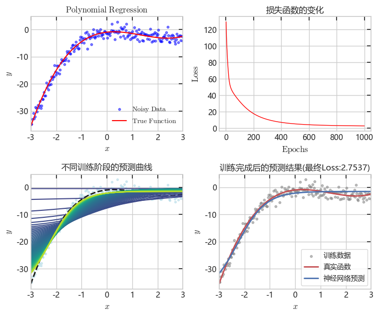

```python
import numpy as np
import matplotlib.pyplot as plt

plt.rcParams['font.sans-serif'] = ['Microsoft YaHei', 'SimHei', 'DejaVu Sans']
plt.rcParams['axes.unicode_minus'] = False
plt.rcParams['mathtext.fontset'] = 'cm'
plt.rcParams['xtick.direction'] = 'in'
plt.rcParams['ytick.direction'] = 'in'
plt.rcParams['xtick.top'] = True
plt.rcParams['ytick.right'] = True

def true_function(x):
    return 0.5 * x**3 - 2*x**2 + x - 1

x_data = np.linspace(-3, 3, 200).reshape(-1, 1)

np.random.seed(42)
noise = np.random.normal(0, 1.5, size=x_data.shape)
y_data = true_function(x_data) + noise
print(x_data[:5])
print(y_data[:5])


def sigmoid(z):
    return 1/(1+np.exp(-np.clip(z,-500,500)))

def sigmoid_derivative(a):
    return a * (1 - a)


INPUT_SIZE = 1
HIDDEN_SIZE = 10
OUTPUT_SIZE = 1
LEARNING_RATE = 0.01
EPOCHS = 1000


def initialize_parameters(input_size, hidden_size, output_size):
    np.random.seed(1)
    parameters = {
        'W1': np.random.randn(input_size, hidden_size)*0.01,
        'b1': np.zeros((hidden_size,1)),
        'W2': np.random.randn(hidden_size, output_size)*0.01,
        'b2': np.zeros((output_size,1))
    }
    return parameters

params = initialize_parameters(INPUT_SIZE, HIDDEN_SIZE, OUTPUT_SIZE)

##  print parameters
print("W1 shape:", params['W1'].shape)
print(params['W1'])
print("b1 shape:", params['b1'].shape)
print(params['b1'])
print("W2 shape:", params['W2'].shape)
print(params['W2'])
print("b2 shape:", params['b2'].shape)
print(params['b2'])


def forward_propagation(X, parameters):
    W1, b1 = parameters['W1'], parameters['b1']
    W2, b2 = parameters['W2'], parameters['b2']

    Z1 = np.dot(X, W1) + b1.T
    A1 = sigmoid(Z1)
    Z2 = np.dot(A1, W2) + b2.T
    A2 = Z2
    cache = {
        'X': X,
        'Z1': Z1,
        'A1': A1,
        'Z2': Z2,
        'A2': A2
    }
    return A2, cache

a2, _ = forward_propagation(x_data, params)
print("Output of forward propagation (A2):", a2)


## 损失函数

def compute_loss(y_pred, y_true):
    m = y_true.shape[0]
    loss = (1/m) * np.sum((y_pred - y_true)**2)
    return loss

a2, cache = forward_propagation(x_data, params)
loss = compute_loss(a2, y_data)
print("Loss:", loss)


def backward_propagation(parameters, cache, X, y_true):
    m = X.shape[0]
    W2 = parameters['W2']
    A1 = cache['A1']
    A2 = cache['A2']
    Z1 = cache['Z1']

    # dZ2 已包含 (2/m)，后续不再除以 m
    dZ2 = (2/m) * (A2 - y_true)
    dW2 = np.dot(A1.T, dZ2)        # 修正：去掉 /m
    db2 = np.sum(dZ2, axis=0, keepdims=True)  # 修正：去掉 /m

    dA1 = np.dot(dZ2, W2.T)
    dZ1 = dA1 * sigmoid_derivative(A1)
    dW1 = np.dot(X.T, dZ1)         # 修正：去掉 /m
    db1 = np.sum(dZ1, axis=0, keepdims=True)  # 修正：去掉 /m

    grads = {
        'dW1': dW1,
        'db1': db1,
        'dW2': dW2,
        'db2': db2
    }
    return grads


def update_parameters(parameters, grads, learning_rate):
    parameters['W1'] -= learning_rate * grads['dW1']
    parameters['b1'] -= learning_rate * grads['db1'].T
    parameters['W2'] -= learning_rate * grads['dW2']
    parameters['b2'] -= learning_rate * grads['db2'].T
    return parameters

##  训练准备

parms = initialize_parameters(INPUT_SIZE, HIDDEN_SIZE, OUTPUT_SIZE)
loss_history = []
snapshot = []
x_test = np.linspace(-3, 3, 100).reshape(-1, 1)

for epoch in range(1, EPOCHS + 1):
    #前向传播
    y_pred, cache = forward_propagation(x_data, parms)
    #计算损失
    loss = compute_loss(y_pred, y_data)
    loss_history.append(loss)

    #反向传播
    grads = backward_propagation(parms, cache, x_data, y_data)
    #更新参数
    parms = update_parameters(parms, grads, LEARNING_RATE)

    if epoch % 10 == 0 or epoch == 1 or epoch == EPOCHS:
        y_curve, _ = forward_propagation(x_test, parms)
        try:
            y_curve_flat = y_curve.ravel()
        except Exception:
            y_curve_flat = np.array(y_curve).reshape(-1)
        snapshot.append((epoch, y_curve_flat))
        print(f"Epoch {epoch}/{EPOCHS}, Loss: {loss:.4f}")


# ========== 四合一子图（2×2 布局） ==========
fig, axes = plt.subplots(2, 2, figsize=(7.75, 6.5))

# --- 子图1：原始数据与真实函数 ---
ax1 = axes[0, 0]
ax1.scatter(x_data, y_data, s=10, color='blue', alpha=0.5, label='$\mathrm{Noisy\ Data}$')
x_true = np.linspace(-3, 3, 100).reshape(-1, 1)
y_true = true_function(x_true)
ax1.plot(x_true, y_true, color='red', label='$\mathrm{True\ Function}$')
ax1.set_xlabel('$x$', fontsize=12)
ax1.set_ylabel('$y$', fontsize=12)
ax1.set_xlim(-3., 3.)
ax1.set_title('$\mathrm{Polynomial\ Regression}$', fontsize=12)
ax1.legend(loc='lower right', frameon=False, fontsize=10)

# --- 子图2：损失曲线 ---
ax2 = axes[0, 1]
ax2.plot(range(1, EPOCHS + 1), loss_history, color='red', linewidth=1)
ax2.set_xlabel('$\mathrm{Epochs}$', fontsize=12)
ax2.set_ylabel('$\mathrm{Loss}$', fontsize=12)
ax2.set_title('损失函数的变化', fontsize=12)

# --- 子图3：不同训练阶段的预测曲线 ---
ax3 = axes[1, 0]
ax3.scatter(x_data, y_data, s=8, color='lightblue', alpha=0.5, label='训练数据')
x_curve = np.linspace(-3, 3, 100).reshape(-1, 1)
ax3.plot(x_curve, true_function(x_curve), 'k--', linewidth=2, label='真实函数')

colors = plt.cm.viridis(np.linspace(0.2, 0.9, len(snapshot)))
for (epoch, y_curve_pred), color in zip(snapshot, colors):
    ax3.plot(x_curve, y_curve_pred, color=color, linewidth=1.5, label=f'Epoch {epoch}')

ax3.set_xlabel('$x$', fontsize=12)
ax3.set_ylabel('$y$', fontsize=12)
ax3.set_xlim(-3., 3.)
ax3.set_title('不同训练阶段的预测曲线', fontsize=12)
#ax3.legend(loc='lower right', fontsize=8)

# --- 子图4：训练完成后的预测结果 ---
ax4 = axes[1, 1]
y_final_pred, _ = forward_propagation(x_test, parms)  # 修正：使用已训练的 parms
ax4.scatter(x_data, y_data, s=10, color='gray', alpha=0.5, label='训练数据')
ax4.plot(x_curve, true_function(x_curve), 'r-', linewidth=2, label='真实函数')
ax4.plot(x_curve, y_final_pred, 'b-', linewidth=2, label='神经网络预测')
ax4.set_xlabel('$x$', fontsize=12)
ax4.set_ylabel('$y$', fontsize=12)
ax4.set_xlim(-3., 3.)
ax4.set_title(f'训练完成后的预测结果(最终Loss:{loss_history[-1]:.4f})', fontsize=12)
ax4.legend(fontsize=10)

plt.tight_layout()
plt.savefig('./data_fig/fig9_combined_figure.png', dpi=300, bbox_inches='tight')
plt.show()
```

机器学习：Pytorch的实现——与NumPy版本完全一致的架构

自动求导：无需手动推导梯度，调用.backward()

动态计算图

GPU加速

模块化API

```python
import torch
import torch.nn as nn
import torch.optim as optim
import numpy as np
import matplotlib.pyplot as plt
```

```python
np.random.seed(42)
torch.manual_seed(42)

def true_func(x):
    return 0.5 * x**3 - 2*x**2 + x - 1

x_train_np = np.linspace(-3, 3, 200).reshape(-1, 1)
noise = np.random.normal(0, 1.5, size=x_train_np.shape)
y_train_np = true_func(x_train_np) + noise
x_train = torch.from_numpy(x_train_np).float()       ##  转换为PyTorch张量 （float32类型，神经网络训练常用）
y_train = torch.from_numpy(y_train_np).float()
class SimpleNN(nn.Module):
    def __init__(self):
        super(SimpleNN, self).__init__()
        self.hidden = nn.Linear(1, 10)
        self.output = nn.Linear(10, 1)

    def forward(self, x):
        x = torch.sigmoid(self.hidden(x))
        x = self.output(x)
        return x
model = SimpleNN()
criterion = nn.MSELoss()
optimizer = optim.Adam(model.parameters(), lr=0.01)
loss_history = []
snapshot = []
x_test_np = np.linspace(-3, 3, 100).reshape(-1, 1)
x_test = torch.from_numpy(x_test_np).float()          ## 生成测试/绘图用的密集点（用于绘制光滑曲线）
```

定义神经网络模型（继承nn.Module）

结构：输入层，隐藏层，偏置量，线性层，输出层

```python
class SimpleNN(nn.Module):
    def __init__(self, input_size, hidden_size, output_size):
        super(SimpleNN, self).__init__()
        self.fc1 = nn.Linear(input_size, hidden_size, bias=True)
        self.fc2 = nn.Linear(hidden_size, output_size, bias=True)

        self.sigmoid = nn.Sigmoid()

    def forward(self, x):
        out = self.fc1(x)               ## 线性变换 Z1 = X*W1 + b1
        out = self.sigmoid(out)         ## 激活函数 A1 = sigmoid(Z1)
        out = self.fc2(out)             ## 线性变换 Z2 = A1*W2 + b2 (输出层通常不加激活函数，直接输出预测值)
        return out
```

```python
## 实例化模型：输入1维，隐藏层10个神经元，输出1维
model = SimpleNN(input_size=1, hidden_size=10, output_size=1)

## 定义损失函数：均方误差MSE
criterion = nn.MSELoss()

## 定义优化器：Adam优化器，学习率0.01, 动量参数momentum=0.0（纯梯度下降）
optimizer = optim.SGD(model.parameters(), lr=0.01, momentum=0.0)
```

训练循环（带损失记录+中间状态快照）

```python
EPOCHS = 5000
loss_history = []    ## 存储每个epoch的损失值，用于后续绘制损失曲线
snapshot = []        ## 存储（epoch, loss）元组，用于后续绘制训练过程中的预测曲线

for epoch in range(1, EPOCHS + 1):
    # 将模型设置为训练模式
    model.train()

    # 前向传播
    y_pred = model(x_train)              # 计算模型的预测值
    loss = criterion(y_pred, y_train)    # 计算损失值

    # 反向传播三部曲
    optimizer.zero_grad()    # 将梯度初始化为零
    loss.backward()          # 自动求导，计算所有参数的梯度
    optimizer.step()         # 根据梯度更新参数（执行梯度下降）

    # 存储损失值
    loss_history.append(loss.item())
    # 每10个epoch或第1个epoch或最后一个epoch时，存储当前的预测曲线
    if epoch % 500 == 0 or epoch == 1 or epoch == EPOCHS:
        model.eval()  # 切换到评估模式，不更新梯度
        with torch.no_grad():
            y_curve_pred = model(x_test).numpy().flatten()  # 获取当前模型在测试点上的预测值
        snapshot.append((epoch, y_curve_pred))  # 存储当前epoch和对应的预测曲线
        print(f"Epoch {epoch}/{EPOCHS}, Loss: {loss.item():.4f}")

print("PyTorch模型训练完成！")
```

```
PyTorch模型训练完成！
```

可视化训练过程 & 拟合结果（与nn.py风格一致）

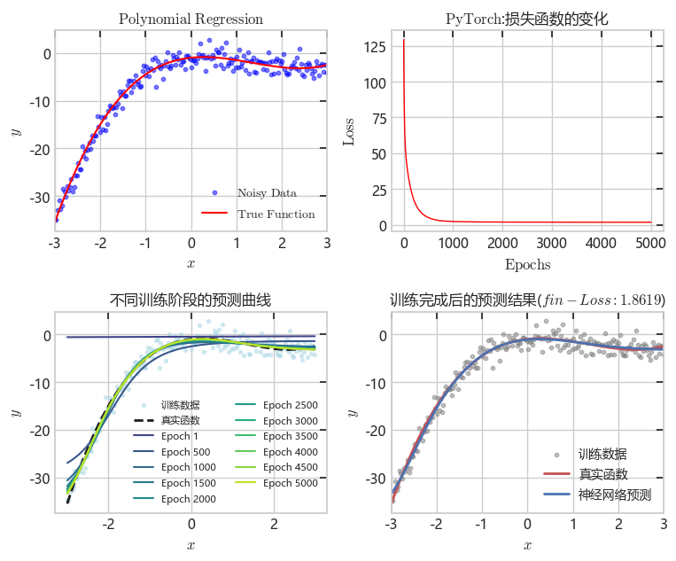

```python
fig, axes = plt.subplots(2, 2, figsize=(7.75, 6.5))

# --- 子图1：原始数据与真实函数 ---
ax1 = axes[0, 0]
ax1.scatter(x_train_np, y_train_np, s=10, color='blue', alpha=0.5, label='$\mathrm{Noisy\ Data}$')
x_true = np.linspace(-3, 3, 100).reshape(-1, 1)
y_true = true_func(x_true)
ax1.plot(x_true, y_true, color='red', label='$\mathrm{True\ Function}$')
ax1.set_xlabel('$x$', fontsize=12)
ax1.set_ylabel('$y$', fontsize=12)
ax1.set_xlim(-3., 3.)
ax1.set_title('$\mathrm{Polynomial\ Regression}$', fontsize=12)
ax1.legend(loc='lower right', frameon=False, fontsize=10)

# --- 子图2：损失曲线 ---

ax2 = axes[0, 1]
ax2.plot(range(1, EPOCHS + 1), loss_history, color='red', linewidth=1)
ax2.set_xlabel('$\mathrm{Epochs}$', fontsize=12)
ax2.set_ylabel('$\mathrm{Loss}$', fontsize=12)
ax2.set_title('$\mathrm{PyTorch}$:损失函数的变化', fontsize=12)

# --- 子图3：不同训练阶段的预测曲线对比（类似于mid-curve.pdf） ---

ax3 = axes[1, 0]
ax3.scatter(x_train_np, y_train_np, s=8, color='lightblue', alpha=0.5, label='训练数据')
x_curve = np.linspace(-3, 3, 100).reshape(-1, 1)
ax3.plot(x_curve, true_func(x_curve), 'k--', linewidth=2, label='真实函数')
colors = plt.cm.viridis(np.linspace(0.2, 0.9, len(snapshot)))
for (epoch, y_curve_pred), color in zip(snapshot, colors):
    ax3.plot(x_curve, y_curve_pred, color=color, linewidth=1.5, label=f'Epoch {epoch}')
ax3.set_xlabel('$x$', fontsize=12)
ax3.set_ylabel('$y$', fontsize=12)
ax3.set_title('不同训练阶段的预测曲线', fontsize=12)
ax3.legend(loc='lower right', frameon=False, fontsize=8, ncol=2)

# --- 子图4：训练完成后的预测结果 ---

ax4 = axes[1, 1]
y_final_pred = model(x_test).detach().numpy().flatten()  # 获取最终模型在测试点上的预测值
ax4.scatter(x_train_np, y_train_np, s=10, color='gray', alpha=0.5, label='训练数据')
ax4.plot(x_curve, true_func(x_curve), 'r-', linewidth=2, label='真实函数')
ax4.plot(x_curve, y_final_pred, 'b-', linewidth=2, label='神经网络预测')
ax4.set_xlabel('$x$', fontsize=12)
ax4.set_ylabel('$y$', fontsize=12)
ax4.set_xlim(-3., 3.)
ax4.set_title(f'训练完成后的预测结果($fin-Loss:{loss_history[-1]:.4f}$)', fontsize=12)
ax4.legend(loc='lower right', frameon=False, fontsize=10)
plt.tight_layout()
#plt.savefig('torch_0083_lpa.png', dpi=300, bbox_inches='tight')
plt.show()
```

多维神经元的实现（优化神经网络预测曲线）

激活函数：nn.Sigmoid，nn.ReLU，nn.Tanh,nn.GELU

```
Epoch [1/5000], Loss: 101.392784
Epoch [500/5000], Loss: 2.798231
Epoch [1000/5000], Loss: 2.740979
Epoch [1500/5000], Loss: 2.834189
Epoch [2000/5000], Loss: 2.808304
Epoch [2500/5000], Loss: 2.455343
Epoch [3000/5000], Loss: 2.672646
Epoch [3500/5000], Loss: 2.153370
Epoch [4000/5000], Loss: 2.451415
Epoch [4500/5000], Loss: 2.393881
Epoch [5000/5000], Loss: 2.534617

Comparison at key points:
x=-2 -> True: -13.000, Predicted: -12.646, Error: 0.3544
x=-1 -> True:  -2.500, Predicted:  -3.059, Error: 0.5585
x= 0 -> True:   1.000, Predicted:   1.291, Error: 0.2908
x= 1 -> True:   0.500, Predicted:   0.583, Error: 0.0830
x= 2 -> True:  -1.000, Predicted:  -0.526, Error: 0.4736
x= 3 -> True:  -0.500, Predicted:  -0.472, Error: 0.0285
```

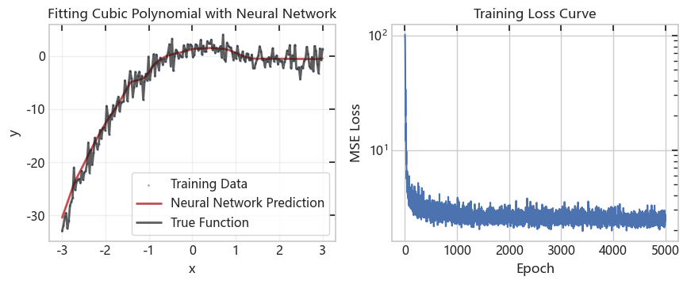

```python
import torch
import torch.nn as nn
import torch.optim as optim
import numpy as np
import matplotlib.pyplot as plt

# 设置随机种子
torch.manual_seed(42)

# 1. 生成数据
x = np.linspace(-3, 3, 200)
noise = np.random.normal(0, 1.5, x.shape)
y = 0.5 * x**3 - 2 * x**2 + x + 1 + noise

# 转换为PyTorch张量
x_tensor = torch.tensor(x, dtype=torch.float32).reshape(-1, 1)
y_tensor = torch.tensor(y, dtype=torch.float32).reshape(-1, 1)

# 2. 定义神经网络模型
class SimpleNet(nn.Module):
    def __init__(self, drop=0.1):
        super(SimpleNet, self).__init__()
        self.net = nn.Sequential(
            nn.Linear(1, 32),
            nn.ReLU(), nn.Dropout(drop),
            nn.Linear(32, 48), nn.Dropout(drop),
            nn.ReLU(),
            nn.Linear(48, 32),
            nn.ReLU(),
            nn.Linear(32, 1)
        )

    def forward(self, x):
        return self.net(x)

# 3. 初始化模型、损失函数和优化器
model = SimpleNet()
criterion = nn.MSELoss()
#optimizer = optim.Adam(model.parameters(), lr=0.01)
optimizer = optim.Adam(model.parameters(),lr=0.01,weight_decay=0.01)

# 4. 训练模型
epochs = 5000
train_losses = []

for epoch in range(epochs):
    # 前向传播
    predictions = model(x_tensor)
    loss = criterion(predictions, y_tensor)

    # 反向传播
    optimizer.zero_grad()
    loss.backward()
    optimizer.step()

    train_losses.append(loss.item())

    # 每500个epoch打印一次损失
    if (epoch + 1) % 500 == 0 or epoch == 0 or epoch == epochs:
        print(f'Epoch [{epoch+1}/{epochs}], Loss: {loss.item():.6f}')

# 5. 预测和可视化
model.eval()
with torch.no_grad():
    y_pred = model(x_tensor).numpy()

# 绘制结果
plt.figure(figsize=(8.85, 3.75))

# 左图：拟合曲线
plt.subplot(1, 2, 1)
plt.scatter(x, y, s=1, alpha=0.5, label='Training Data')
plt.plot(x, y_pred, 'r-', linewidth=2, label='Neural Network Prediction')
plt.plot(x, y, 'k-', linewidth=2, alpha=0.7, label='True Function')
plt.xlabel('x')
plt.ylabel('y')
plt.title('Fitting Cubic Polynomial with Neural Network')
plt.legend()
plt.grid(True, alpha=0.3)

# 右图：损失曲线
plt.subplot(1, 2, 2)
plt.plot(train_losses)
plt.xlabel('Epoch')
plt.ylabel('MSE Loss')
plt.title('Training Loss Curve')
plt.yscale('log')
#plt.grid(True, alpha=0.3)

plt.tight_layout()
#plt.savefig('loss.pdf')

# 6. 打印对比结果
print("\nComparison at key points:")
x_test = torch.tensor([[-2.0], [-1.0], [0.0], [1.0], [2.0], [3.0]])
with torch.no_grad():
    y_test_pred = model(x_test).numpy()

for i, xi in enumerate([-2, -1, 0, 1, 2, 3]):
    y_true = 0.5 * xi**3 - 2 * xi**2 + xi + 1
    print(f"x={xi:2d} -> True: {y_true:7.3f}, Predicted: {y_test_pred[i][0]:7.3f}, Error: {abs(y_true - y_test_pred[i][0]):.4f}")

plt.savefig('./data_fig/fig10_fitting_and_loss.png', dpi=300, bbox_inches='tight')
# print(train_losses)
```

作业：

起因：深度神经网络具有极高容量，容易记住训练集的噪声。

正则化：通过引入额外约束（结构风险最小化）来降低假设空间的有效容量。

Dropout：随机丢弃神经元，防止神经元之间复杂的共适应。

早停：早停的核心逻辑是监控验证集上的一个指标（如损失函数），一旦它在指定次数的训练周期内不再改善，训练过程就会自动终止，从而节省时间并防止过拟合。

期末作业：神经网络的优化方案

为什么大网络会导致锯齿状不平滑？

Torch的结构

```python
import torch
import torch.nn as nn
import torch.optim as optim
import torchvision
import torchvision.transforms as transforms
import matplotlib.pyplot as plt
import numpy as np
```

```python
pip install torchvision
```

```python
import torch
import torch.nn as nn
import torch.optim as optim
import torchvision
import torchvision.transforms as transforms
import matplotlib.pyplot as plt
import numpy as np
```

```python
device = torch.device('cuda' if torch.cuda.is_available() else 'cpu')
print(f'Using device: {device}')
```

```
Using device: cpu
```

图像预处理：先转为张量，再标准化

```python
transforms = transforms.Compose([
    transforms.Resize((28, 28)),   # 第一步：缩放
    transforms.ToTensor(),         # 第二步：转换为张量
    transforms.Normalize((0.1307,),(0.3081,))  ## 均值：0.1307，标准差：0.3081
])
```

```python
train_dataset = torchvision.datasets.MNIST(
    root='./data',train=True,transform=transforms,download=True)
test_dataset = torchvision.datasets.MNIST(
    root='./data',train=False,transform=transforms,download=True)

batch_size = 64
train_loader = torch.utils.data.DataLoader(
    dataset=train_dataset,batch_size=batch_size,shuffle=True)
test_loader = torch.utils.data.DataLoader(
    dataset=test_dataset,batch_size=batch_size,shuffle=False)
```

```python
data_iter = iter(train_loader)
images, labels = next(data_iter)

print("Batch of images shape:", images.shape)  ## 形状为 (batch_size, channels, height, width)
print("Batch of labels shape:", labels.shape)  ## 形状为 (batch_size,)
```

```
Batch of images shape: torch.Size([64, 1, 28, 28])
Batch of labels shape: torch.Size([64])
```

```
SimpleMLP(
  (fc1): Linear(in_features=784, out_features=128, bias=True)
  (fc2): Linear(in_features=128, out_features=128, bias=True)
  (fc3): Linear(in_features=128, out_features=10, bias=True)
  (dropout): Dropout(p=0.2, inplace=False)
  (relu): ReLU()
)
Epoch [1/10], Loss: 0.3221
Epoch [2/10], Loss: 0.1585
Epoch [3/10], Loss: 0.1274
Epoch [4/10], Loss: 0.1096
Epoch [5/10], Loss: 0.0980
Epoch [6/10], Loss: 0.0873
Epoch [7/10], Loss: 0.0811
Epoch [8/10], Loss: 0.0757
Epoch [9/10], Loss: 0.0727
Epoch [10/10], Loss: 0.0662
Accuracy: 97.96%
```

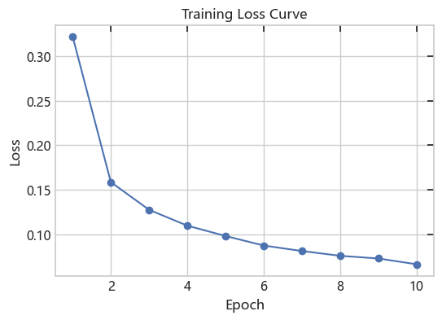

```python
class SimpleMLP(nn.Module):
    def __init__(self):
        super(SimpleMLP, self).__init__()
        self.fc1 = nn.Linear(28 * 28, 128)  ## 全连接层，输入特征数784，输出128
        self.fc2 = nn.Linear(128, 128)       ## 全连接层，输入128，输出10（类别数）
        self.fc3 = nn.Linear(128, 10)        ## 全连接层，输入128，输出10（类别数）
        self.dropout = nn.Dropout(0.2)        ## Dropout层，丢弃率20%
        self.relu = nn.ReLU()                ## ReLU激活函数

    def forward(self, x):
        x = x.view(-1, 28 * 28)  ## 展平为 (batch_size, 784)
        x = torch.relu(self.fc1(x))  ## 全连接 -> 激活
        x = self.dropout(x)          ## Dropout
        x = torch.relu(self.fc2(x))  ## 全连接 -> 激活
        x = self.dropout(x)          ## Dropout
        x = self.fc3(x)              ## 全连接（输出层）
        return x
        self.fc1 = nn.Linear(32 * 7 * 7, 128)  ## 全连接层，输入特征数32*7*7，输出128
        self.fc2 = nn.Linear(128, 10)            ## 全连接层，输入128，输出10（类别数）

model = SimpleMLP().to(device)
print(model)

criterion = nn.CrossEntropyLoss()  ## 交叉熵损失函数，适用于多分类问题
optimizer = optim.Adam(model.parameters(), lr=0.001)  ## Adam优化器，学习率0.001
num_epochs = 10
train_losses = []
for epoch in range(num_epochs):
    model.train()  ## 设置模型为训练模式
    running_loss = 0.0
    for images, labels in train_loader:
        images, labels = images.to(device), labels.to(device)  ## 将数据移动到GPU（如果可用）
        optimizer.zero_grad()  ## 清零梯度
        outputs = model(images)  ## 前向传播

        # 反向传播和优化
        optimizer.zero_grad()
        loss = criterion(outputs, labels)  ## 计算损失
        loss.backward()  ## 反向传播
        optimizer.step()  ## 更新参数
        running_loss += loss.item() * images.size(0)  ## 累积损失（乘以批量大小）
    epoch_loss = running_loss / len(train_loader.dataset)  ## 计算平均损失
    train_losses.append(epoch_loss)
    print(f'Epoch [{epoch+1}/{num_epochs}], Loss: {epoch_loss:.4f}')


model.eval()  ## 设置模型为评估模式
correct = 0
total = 0
with torch.no_grad():  ## 不计算梯度
    for images, labels in test_loader:
        images, labels = images.to(device), labels.to(device)
        outputs = model(images)
        _, predicted = torch.max(outputs.data, 1)
        total += labels.size(0)
        correct += (predicted == labels).sum().item()
print(f'Accuracy: {100 * correct / total:.2f}%')
plt.figure(figsize=(6, 4))
plt.plot(range(1, num_epochs + 1), train_losses, marker='o')
plt.xlabel('Epoch')
plt.ylabel('Loss')
plt.title('Training Loss Curve')
plt.savefig('./data_fig/fig11_mnist_loss_curve.png', dpi=300, bbox_inches='tight')
plt.show()
```

```python
data_inter = iter(test_loader)
images, labels = next(data_inter)
images, labels = images.to(device), labels.to(device)
outputs = model(images)
_, predicted = torch.max(outputs.data, 1)
print("Predicted labels:", predicted.cpu().numpy())
print("True labels:", labels.cpu().numpy())
```

```
Predicted labels: [7 2 1 0 4 1 4 9 5 9 0 6 9 0 1 5 9 7 3 4 9 6 6 5 4 0 7 4 0 1 3 1 3 4 7 2 7
 1 2 1 1 7 4 2 3 5 1 2 4 4 6 3 5 5 6 0 4 1 9 5 7 8 9 3]
True labels: [7 2 1 0 4 1 4 9 5 9 0 6 9 0 1 5 9 7 3 4 9 6 6 5 4 0 7 4 0 1 3 1 3 4 7 2 7
 1 2 1 1 7 4 2 3 5 1 2 4 4 6 3 5 5 6 0 4 1 9 5 7 8 9 3]
```

```
Using device: cpu
Epoch [1/10], Loss: 0.3182
Epoch [2/10], Loss: 0.1558
Epoch [3/10], Loss: 0.1232
Epoch [4/10], Loss: 0.1102
Epoch [5/10], Loss: 0.0919
Epoch [6/10], Loss: 0.0851
Epoch [7/10], Loss: 0.0780
Epoch [8/10], Loss: 0.0733
Epoch [9/10], Loss: 0.0691
Epoch [10/10], Loss: 0.0650
Accuracy: 98.11%
```

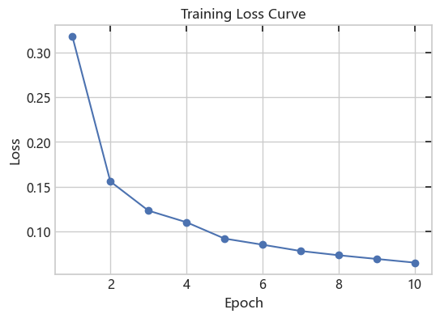

```python
import torch
import torch.nn as nn
import torch.optim as optim
import torchvision
import torchvision.transforms as transforms
import matplotlib.pyplot as plt

device = torch.device('cuda' if torch.cuda.is_available() else 'cpu')
print(f'Using device: {device}')
transform = transforms.Compose([
    transforms.ToTensor(),
    transforms.Normalize((0.1307,), (0.3081,))
])
train_dataset = torchvision.datasets.MNIST(root='./data', train=True, transform=transform, download=True)
test_dataset = torchvision.datasets.MNIST(root='./data', train=False, transform=transform, download=True)
train_loader = torch.utils.data.DataLoader(dataset=train_dataset, batch_size=64, shuffle=True)
test_loader = torch.utils.data.DataLoader(dataset=test_dataset, batch_size=64, shuffle=False)
class SimpleMLP(nn.Module):
    def __init__(self):
        super(SimpleMLP, self).__init__()
        self.fc1 = nn.Linear(28 * 28, 128)
        self.fc2 = nn.Linear(128, 128)
        self.fc3 = nn.Linear(128, 10)
        self.dropout = nn.Dropout(0.2)
        self.relu = nn.ReLU()

    def forward(self, x):
        x = x.view(-1, 28 * 28)
        x = torch.relu(self.fc1(x))
        x = self.dropout(x)
        x = torch.relu(self.fc2(x))
        x = self.dropout(x)
        x = self.fc3(x)
        return x

model = SimpleMLP().to(device)
criterion = nn.CrossEntropyLoss()
optimizer = optim.Adam(model.parameters(), lr=0.001)

num_epochs = 10
train_losses = []
for epoch in range(num_epochs):
    model.train()
    running_loss = 0.0
    for images, labels in train_loader:
        images, labels = images.to(device), labels.to(device)
        optimizer.zero_grad()
        outputs = model(images)
        loss = criterion(outputs, labels)
        loss.backward()
        optimizer.step()
        running_loss += loss.item() * images.size(0)
    epoch_loss = running_loss / len(train_loader.dataset)
    train_losses.append(epoch_loss)
    print(f'Epoch [{epoch+1}/{num_epochs}], Loss: {epoch_loss:.4f}')

model.eval()
correct = 0
total = 0
with torch.no_grad():
    for images, labels in test_loader:
        images, labels = images.to(device), labels.to(device)
        outputs = model(images)
        _, predicted = torch.max(outputs.data, 1)
        total += labels.size(0)
        correct += (predicted == labels).sum().item()
print(f'Accuracy: {100 * correct / total:.2f}%')
plt.figure(figsize=(6, 4))
plt.plot(range(1, num_epochs + 1), train_losses, marker='o')
plt.xlabel('Epoch')
plt.ylabel('Loss')
plt.title('Training Loss Curve')
plt.savefig('./data_fig/fig12_mnist_loss_curve.png', dpi=300, bbox_inches='tight')
plt.show()
```

[figure not shown]

```python
model.eval()

# 选择前10个样本（如果 images/labels 已经是 batch，直接取前10个）
images = images[:10]
labels = labels[:10]

device = next(model.parameters()).device
images = images.to(device)

# 前向传播，获取预测结果
with torch.no_grad():  # 关闭梯度计算，节省内存
    outputs = model(images)  # 输出形状通常是 [batch_size, 10]
    preds = outputs.argmax(dim=1)  # 取概率最大的类别作为预测

# 将预测结果移回 CPU（因为 matplotlib 需要 numpy）
preds = preds.cpu()


fig, axes = plt.subplots(2, 5, figsize=(10, 4))
axes = axes.ravel()

for i in range(10):
    img = images[i].cpu().numpy().squeeze() #形状 [28,28]

    #反标准化以便显示:img=img*std+mean
    img= img *0.308+0.1307
    axes[i].imshow(img, cmap='gray')
    axes[i].set_title(f"Real: {labels[i].item()}, Pred: {preds[i].item()}", color='green' if labels[i] == preds[i] else 'red')
    axes[i].axis('off')
plt.tight_layout()
plt.savefig('./data_fig/fig13_mnist_predictions.png', dpi=300, bbox_inches='tight')
plt.show()
```

为什么需要标准化？神经网络对数值大小极度敏感，数值差距太大导致：训练变慢，很难收敛；模型不收敛，完全学不会；梯度爆炸。

图像预处理的流程是什么？

图像读进程序之后，会变成数字张量（数组）transforms.Totensor()

普通黑白图像：每个像素取值范围0~255（0=纯黑，255=纯白）

标准化：

思考：Dropout在训练和评估时的行为差异

```
使用设备：cpu
Epoch [1/10], Loss: 0.3186
Epoch [2/10], Loss: 0.1540
Epoch [3/10], Loss: 0.1233
Epoch [4/10], Loss: 0.1055
Epoch [5/10], Loss: 0.0900
Epoch [6/10], Loss: 0.0870
Epoch [7/10], Loss: 0.0777
Epoch [8/10], Loss: 0.0707
Epoch [9/10], Loss: 0.0694
Epoch [10/10], Loss: 0.0649
Test accuracy: 97.89%
```

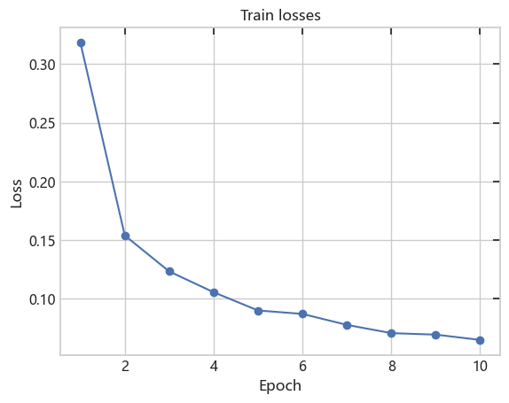

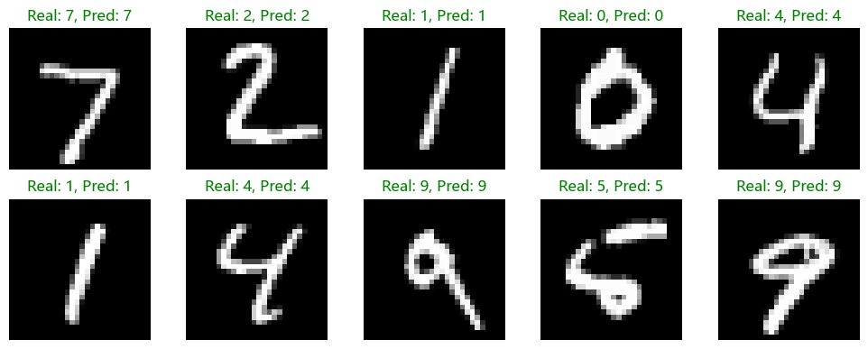

```python
import torch
import torch.nn as nn
import torch.optim as optim
import torchvision
import torchvision.transforms as transforms
import matplotlib.pyplot as plt
import numpy as np

device = torch.device("cuda" if torch.cuda.is_available() else "cpu")
print(f"使用设备：{device}")

transform = transforms.Compose([
transforms.ToTensor(),  # 值范围自动变为 [0, 1]
transforms.Normalize((0.1307,), (0.3081,))  # 均值0.1307，标准差0.3081
])

train_dataset = torchvision.datasets.MNIST(
    root='./data', train=True, transform=transform, download=True)
test_dataset = torchvision.datasets.MNIST(
    root='./data', train=False, transform=transform, download=True)

batch_size = 64
train_loader = torch.utils.data.DataLoader(
    dataset=train_dataset, batch_size=batch_size, shuffle=True)
test_loader = torch.utils.data.DataLoader(
    dataset=test_dataset, batch_size=batch_size, shuffle=False)

data_iter = iter(train_loader)
# iter(iterable) 从可迭代对象中获取一个迭代器，执行 data_iter = iter(train_loader) 后，data_iter 就变成了一个迭代器对象。
images, labels = next(data_iter)
# next(iterator) 从迭代器中取出下一个元素。每次调用 next(data_iter)，它会返回迭代器所指向的下一个数据项，如 mini-batch 的 (images, labels) 对）。

# print(f"一个批次的图像张量形状：{images.shape}")  # [64, 1, 28, 28]，代表批次大小 64、颜色通道 1（灰度）、高度 28、宽度 28。
# print(f"对应标签形状：{labels.shape}")            # [64]
# print(f"labels: {labels}")

class SimpleMLP(nn.Module):      # 自定义网络需要继承 nn.Module
    def __init__(self):
        super(SimpleMLP, self).__init__()
        self.fc1 = nn.Linear(28*28, 128)   # 输入 784 -> 隐藏层1 128
        self.fc2 = nn.Linear(128, 128)     # 隐藏层1 -> 隐藏层2 128
        self.fc3 = nn.Linear(128, 10)      # 隐藏层2 -> 输出 10
        self.dropout = nn.Dropout(0.2)     # Dropout 概率 0.2
        self.relu = nn.ReLU()

    def forward(self, x):
        # x 形状: [batch, 1, 28, 28]
        x = x.view(-1, 28*28)
        # 拉平为 [batch, 784]
        # view 相当于 numpy 的 reshape，-1 表示让 PyTorch 自动推导第一维大小。
        x = self.relu(self.fc1(x))
        x = self.dropout(x)                # 训练时随机失活
        x = self.relu(self.fc2(x))
        x = self.dropout(x)
        x = self.fc3(x)                    # 输出 logits
        return x

model = SimpleMLP().to(device)
# print(model)

criterion = nn.CrossEntropyLoss()
optimizer = optim.Adam(model.parameters(), lr=0.001)

num_epochs = 10
train_losses = []  # 记录每个 epoch 的平均损失


for epoch in range(num_epochs):
    model.train()  # 切换到训练模式（启用 Dropout）
    running_loss = 0.0
    for images, labels in train_loader:
        images, labels = images.to(device), labels.to(device)

        # 1. 前向传播
        outputs = model(images)
        loss = criterion(outputs, labels)

        # 2. 反向传播与优化
        optimizer.zero_grad()
        loss.backward()
        optimizer.step()

        running_loss += loss.item()

    epoch_loss = running_loss / len(train_loader)
    train_losses.append(epoch_loss)
    print(f"Epoch [{epoch+1}/{num_epochs}], Loss: {epoch_loss:.4f}")

plt.figure()
plt.plot(range(1, num_epochs+1), train_losses, marker='o')
plt.xlabel('Epoch')
plt.ylabel('Loss')
plt.title('Train losses')
plt.grid(True)
plt.savefig("loss.pdf")


model.eval()  # 切换到评估模式
correct = 0  # 统计预测正确的样本数
total = 0  # 统计总样本数
# 不记录梯度
with torch.no_grad():
    for images, labels in test_loader:
        images, labels = images.to(device), labels.to(device)
        outputs = model(images)
        _, predicted = torch.max(outputs, 1)
        # torch.max(outputs, 1) 返回每一行的最大值和对应的索引，索引即预测的数字。
        # 如果我们的全连接网络能达到 97% 以上的准确率，就说明它已经很好地学会了识别手写数字。
        total += labels.size(0)
        correct += (predicted == labels).sum().item()

accuracy = 100 * correct / total
print(f"Test accuracy: {accuracy:.2f}%")

# 取一个测试批次进行可视化
data_iter = iter(test_loader)
images, labels = next(data_iter)
images, labels = images.to(device), labels.to(device)

model.eval()
with torch.no_grad():
    outputs = model(images)
    _, preds = torch.max(outputs, 1)

# 显示前 10 张图片
fig, axes = plt.subplots(2, 5, figsize=(10, 4))
axes = axes.ravel()
for i in range(10):
    img = images[i].cpu().numpy().squeeze()  # 形状 [28,28]
    # 反标准化以便显示：img = img * std + mean
    img = img * 0.3081 + 0.1307
    axes[i].imshow(img, cmap='gray')
    axes[i].set_title(f"Real: {labels[i].item()}, Pred: {preds[i].item()}",
                      color='green' if labels[i] == preds[i] else 'red')
    axes[i].axis('off')
plt.tight_layout()
plt.savefig("./data_fig/fig13_mnist_predictions.png", dpi=300, bbox_inches='tight')
```

```python
torch.save(model.state_dict(), '../mnist_mlp.pth')
print("模型参数已保存到 ../mnist_mlp.pth")
```

```
模型参数已保存到 ../mnist_mlp.pth
```

```
使用设备：cpu
模型加载成功
找到 20 个预测错误样本（显示前 20 个）
```

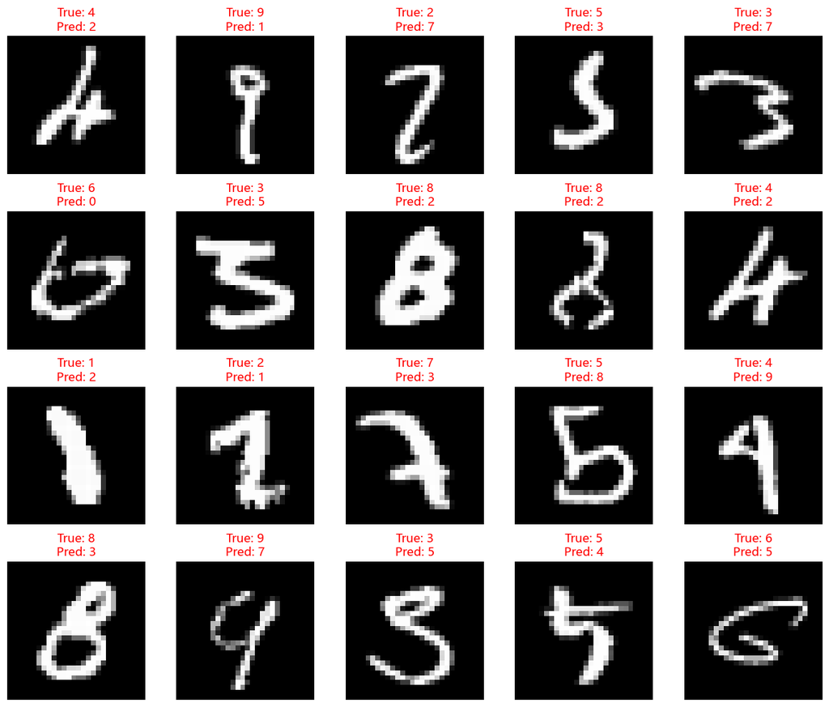

```
错误样本可视化已保存为 error_predictions.pdf
```

```python
import torch
import torch.nn as nn
import torchvision
import torchvision.transforms as transforms
import matplotlib.pyplot as plt

# ------------------------------
# 1. 定义相同的模型结构（必须与训练时一致）
# ------------------------------
class SimpleMLP(nn.Module):
    def __init__(self):
        super(SimpleMLP, self).__init__()
        self.fc1 = nn.Linear(28*28, 128)
        self.fc2 = nn.Linear(128, 128)
        self.fc3 = nn.Linear(128, 10)
        self.dropout = nn.Dropout(0.2)   # 评估模式下 dropout 不起作用，定义即可
        self.relu = nn.ReLU()

    def forward(self, x):
        x = x.view(-1, 28*28)
        x = self.relu(self.fc1(x))
        x = self.dropout(x)
        x = self.relu(self.fc2(x))
        x = self.dropout(x)
        x = self.fc3(x)
        return x

# ------------------------------
# 2. 设备设置
# ------------------------------
device = torch.device("cuda" if torch.cuda.is_available() else "cpu")
print(f"使用设备：{device}")

# ------------------------------
# 3. 加载测试数据集（需要与训练时的预处理一致）
# ------------------------------
transform = transforms.Compose([
    transforms.ToTensor(),
    transforms.Normalize((0.1307,), (0.3081,))
])

test_dataset = torchvision.datasets.MNIST(
    root='./data', train=False, transform=transform, download=False  # 若已下载可设为False
)
test_loader = torch.utils.data.DataLoader(
    dataset=test_dataset, batch_size=64, shuffle=False
)

# ------------------------------
# 4. 加载保存的模型参数
# ------------------------------
model = SimpleMLP().to(device)
model.load_state_dict(torch.load('../mnist_mlp.pth', map_location=device))
model.eval()  # 切换为评估模式（关闭dropout）

print("模型加载成功")

# ------------------------------
# 5. 找出所有预测错误的样本
# ------------------------------
error_images = []      # 存储图像张量（未归一化前的原始值，用于显示）
error_labels = []      # 真实标签
error_preds = []       # 预测标签

with torch.no_grad():
    for images, labels in test_loader:
        images, labels = images.to(device), labels.to(device)
        outputs = model(images)
        _, preds = torch.max(outputs, 1)
        #print(f"----------------\npreds: {preds}")
        #print(f"labels: {labels}")
        # 找出预测错误的索引
        incorrect_mask = (preds != labels)
        #print(f"incorrect_mask: {incorrect_mask}\n")
        if incorrect_mask.any():
            # 收集错误样本（注意需要转移到CPU并保留原始图像）
            error_images.extend(images[incorrect_mask].cpu())
            error_labels.extend(labels[incorrect_mask].cpu())
            error_preds.extend(preds[incorrect_mask].cpu())

        # 如果已经收集够20个，可以提前停止（可选）
        if len(error_images) >= 20:
            break

# 只取前20个（如果不够20则取全部）
num_show = min(20, len(error_images))
error_images = error_images[:num_show]
error_labels = error_labels[:num_show]
error_preds = error_preds[:num_show]

print(f"找到 {len(error_images)} 个预测错误样本（显示前 {num_show} 个）")

# ------------------------------
# 6. 可视化这20个错误样本
# ------------------------------
fig, axes = plt.subplots(4, 5, figsize=(12, 10))  # 4行5列
axes = axes.ravel()

for i in range(num_show):
    img = error_images[i].squeeze().numpy()   # 形状 [28,28]
    # 反标准化：img = img * std + mean
    img = img * 0.3081 + 0.1307
    axes[i].imshow(img, cmap='gray')
    axes[i].set_title(f"True: {error_labels[i].item()}\nPred: {error_preds[i].item()}",
                      color='red')
    axes[i].axis('off')

# 如果不足20个，多余的子图隐藏
for i in range(num_show, 20):
    axes[i].axis('off')

plt.tight_layout()
plt.savefig("./data_fig/fig14_error_predictions.png", dpi=300, bbox_inches='tight')
plt.show()
print("错误样本可视化已保存为 error_predictions.pdf")
```

手写数字，预处理识别

```python
import os
import torch
import torch.nn as nn
from torchvision import transforms
import numpy as np
from PIL import Image
import matplotlib.pyplot as plt

# ------------------------------
# 1. 定义与训练时完全相同的模型结构
# ------------------------------
class SimpleMLP(nn.Module):
    def __init__(self):
        super(SimpleMLP, self).__init__()
        self.fc1 = nn.Linear(28*28, 128)
        self.fc2 = nn.Linear(128, 128)
        self.fc3 = nn.Linear(128, 10)
        self.dropout = nn.Dropout(0.2)   # 评估模式下自动关闭
        self.relu = nn.ReLU()

    def forward(self, x):
        x = x.view(-1, 28*28)
        x = self.relu(self.fc1(x))
        x = self.dropout(x)
        x = self.relu(self.fc2(x))
        x = self.dropout(x)
        x = self.fc3(x)
        return x

# ------------------------------
# 2. 加载预训练模型
# ------------------------------
device = torch.device("cuda" if torch.cuda.is_available() else "cpu")
print(f"使用设备: {device}")

model = SimpleMLP().to(device)
# 请确保模型文件路径正确，可修改为你的实际路径
model.load_state_dict(torch.load('../mnist_mlp.pth', map_location=device))
model.eval()
print("模型加载成功\n")

# ------------------------------
# 3. 图像预处理函数（将手机拍摄的图片转为模型可接受的格式）
# ------------------------------
def preprocess_image(image_path):
    """
    读取一张手写数字图片，输出标准化后的 tensor (1, 1, 28, 28)
    同时返回处理后 28x28 的灰度数组（范围 [0,1]，用于显示）
    """
    # 打开图片，转为灰度模式
    img = Image.open(image_path).convert('L')

    # 反色（手机拍的白纸黑字 -> 黑底白字）
    img = Image.eval(img, lambda x: 255 - x)

    # 调整大小到28x28（双线性插值）
    img = img.resize((28, 28), Image.Resampling.BILINEAR)

    # 转为numpy数组，并转为float类型，归一化到 [0,1]
    img_array = np.array(img, dtype=np.float32) / 255.0

    # 标准化（使用MNIST训练时的均值和标准差）
    transform_norm = transforms.Normalize((0.1307,), (0.3081,))
    img_tensor = torch.from_numpy(img_array).unsqueeze(0)  # 变成 (1, 28, 28)
    img_tensor = transform_norm(img_tensor)
    img_tensor = img_tensor.unsqueeze(0)  # 变成 (1, 1, 28, 28)

    return img_tensor, img_array  # 返回处理后tensor和原始28x28数组（用于显示）

# ------------------------------
# 4. 预测单张图片
# ------------------------------
def predict_single(image_path):
    """
    预测单张图片，返回预测数字、置信度以及处理后的28x28数组
    """
    img_tensor, img_raw = preprocess_image(image_path)
    img_tensor = img_tensor.to(device)

    with torch.no_grad():
        output = model(img_tensor)
        probabilities = torch.nn.functional.softmax(output, dim=1)
        pred = torch.argmax(output, dim=1).item()
        confidence = probabilities[0][pred].item()

    return pred, confidence, img_raw

# ------------------------------
# 5. 批量处理并显示结果（修改后：同时显示原始图片和处理后图片）
# ------------------------------
def process_images(image_folder):
    """
    读取文件夹中的所有常见图片格式，逐一预测并用matplotlib显示
    每个图片显示两列：左边为原始图片，右边为预处理后的28x28图片
    """
    # 支持的图片扩展名
    valid_ext = ('.jpg', '.jpeg', '.png', '.bmp', '.tiff')
    image_files = [f for f in os.listdir(image_folder) if f.lower().endswith(valid_ext)]

    if not image_files:
        print(f"文件夹 '{image_folder}' 中没有找到图片文件。")
        return

    num_images = len(image_files)
    print(f"找到 {num_images} 张图片，开始识别...\n")

    # 子图布局：每个图片占一行两列（左边原始图，右边处理后图）
    n_rows = num_images
    n_cols = 2
    fig, axes = plt.subplots(n_rows, n_cols, figsize=(8, 3 * n_rows), squeeze=False)

    for idx, file_name in enumerate(image_files):
        file_path = os.path.join(image_folder, file_name)
        try:
            pred, conf, img_processed = predict_single(file_path)
            print(f"[{idx+1}] {file_name} -> 预测: {pred} (置信度: {conf:.4f})")

            # 左边：原始图片（彩色或灰度，这里统一用灰度显示）
            original_img = Image.open(file_path).convert('L')
            ax_orig = axes[idx, 0]
            ax_orig.imshow(original_img, cmap='gray')
            ax_orig.set_title(f"Original: {file_name}", fontsize=10)
            ax_orig.axis('off')

            # 右边：预处理后的28x28图片（已经过反色、缩放、归一化）
            ax_proc = axes[idx, 1]
            ax_proc.imshow(img_processed, cmap='gray', vmin=0, vmax=1)
            ax_proc.set_title(f"Processed → Pred: {pred} (Conf: {conf:.2%})", fontsize=10)
            ax_proc.axis('off')

        except Exception as e:
            print(f"处理 {file_name} 时出错: {e}")
            # 出错时清除对应行的两个子图
            axes[idx, 0].axis('off')
            axes[idx, 1].axis('off')

    plt.tight_layout()
    plt.savefig("recognition_test1.pdf", dpi=150)
    print("\n结果图片已保存为 recognition_results_with_processed.pdf")

# ------------------------------
# 6. 主程序入口
# ------------------------------
if __name__ == "__main__":
    # 请修改为你的图片文件夹路径（手机照片存放的目录）
    image_folder = "./img"   # 示例路径，请根据实际情况修改

    # 如果文件夹不存在，提示
    if not os.path.exists(image_folder):
        print(f"错误：文件夹 '{image_folder}' 不存在。")
        print("请修改代码中的 image_folder 变量，指向存放手写数字图片的文件夹。")
    else:
        process_images(image_folder)
```

```
使用设备: cpu
模型加载成功

错误：文件夹 './img' 不存在。
请修改代码中的 image_folder 变量，指向存放手写数字图片的文件夹。
```

卷积神经网络

全连接网络在图像处理任务上的局限性

卷积神经网络实现手写数字识别

```
使用设备：cpu
一个批次的图像张量形状：torch.Size([64, 1, 28, 28])
对应标签形状：torch.Size([64])
Epoch [1/10], Loss: 0.1644
Epoch [2/10], Loss: 0.0571
Epoch [3/10], Loss: 0.0385
Epoch [4/10], Loss: 0.0314
Epoch [5/10], Loss: 0.0261
Epoch [6/10], Loss: 0.0211
Epoch [7/10], Loss: 0.0186
Epoch [8/10], Loss: 0.0159
Epoch [9/10], Loss: 0.0144
Epoch [10/10], Loss: 0.0138
Test accuracy: 99.24%
```

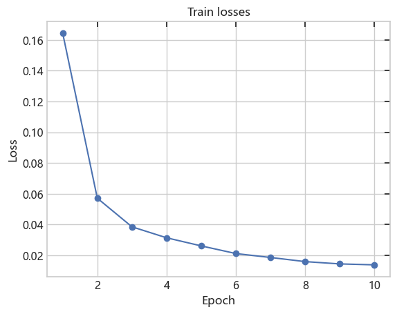

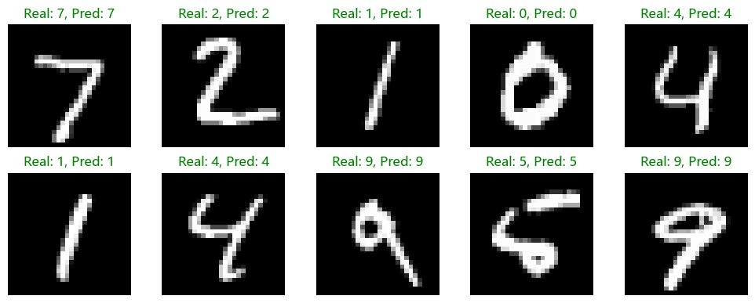

```python
import torch
import torch.nn as nn
import torch.optim as optim
import torchvision
import torchvision.transforms as transforms
import matplotlib.pyplot as plt
import numpy as np

device = torch.device("cuda" if torch.cuda.is_available() else "cpu")
print(f"使用设备：{device}")

transform = transforms.Compose([
transforms.ToTensor(),  # 值范围自动变为 [0, 1]
transforms.Normalize((0.1307,), (0.3081,))  # 均值0.1307，标准差0.3081
])

train_dataset = torchvision.datasets.MNIST(
    root='./data', train=True, transform=transform, download=True)
test_dataset = torchvision.datasets.MNIST(
    root='./data', train=False, transform=transform, download=True)

batch_size = 64
train_loader = torch.utils.data.DataLoader(
    dataset=train_dataset, batch_size=batch_size, shuffle=True)
test_loader = torch.utils.data.DataLoader(
    dataset=test_dataset, batch_size=batch_size, shuffle=False)

data_iter = iter(train_loader)
# iter(iterable) 从可迭代对象中获取一个迭代器，执行 data_iter = iter(train_loader) 后，data_iter 就变成了一个迭代器对象。
images, labels = next(data_iter)
# next(iterator) 从迭代器中取出下一个元素。每次调用 next(data_iter)，它会返回迭代器所指向的下一个数据项，如 mini-batch 的 (images, labels) 对）。

print(f"一个批次的图像张量形状：{images.shape}")  # [64, 1, 28, 28]，代表批次大小 64、颜色通道 1（灰度）、高度 28、宽度 28。
print(f"对应标签形状：{labels.shape}")            # [64]

class SimpleMLP(nn.Module):      # 自定义网络需要继承 nn.Module
    def __init__(self):
        super(SimpleMLP, self).__init__()
        self.fc1 = nn.Linear(28*28, 128)   # 输入 784 -> 隐藏层1 128
        self.fc2 = nn.Linear(128, 128)     # 隐藏层1 -> 隐藏层2 128
        self.fc3 = nn.Linear(128, 10)      # 隐藏层2 -> 输出 10
        self.dropout = nn.Dropout(0.2)     # Dropout 概率 0.2
        self.relu = nn.ReLU()

    def forward(self, x):
        # x 形状: [batch, 1, 28, 28]
        x = x.view(-1, 28*28)
        # 拉平为 [batch, 784]
        # view 相当于 numpy 的 reshape，-1 表示让 PyTorch 自动推导第一维大小。
        x = self.relu(self.fc1(x))
        x = self.dropout(x)                # 训练时随机失活
        x = self.relu(self.fc2(x))
        x = self.dropout(x)
        x = self.fc3(x)                    # 输出 logits
        return x

class SimpleCNN(nn.Module):
    def __init__(self):
        super(SimpleCNN, self).__init__()
        self.conv1 = nn.Conv2d(1, 32, kernel_size=3, padding=1)
        self.conv2 = nn.Conv2d(32, 64, kernel_size=3, padding=1)
        self.pool = nn.MaxPool2d(2, 2)
        self.fc1 = nn.Linear(64 * 7 * 7, 128)  # 经过两次2x2池化后尺寸变为7x7
        self.fc2 = nn.Linear(128, 10)
        self.dropout = nn.Dropout(0.25)
        self.relu = nn.ReLU()

    def forward(self, x):
        x = self.pool(self.relu(self.conv1(x)))  # [batch, 32, 14, 14]
        x = self.pool(self.relu(self.conv2(x)))  # [batch, 64, 7, 7]
        x = x.view(-1, 64 * 7 * 7)
        x = self.relu(self.fc1(x))
        x = self.dropout(x)
        x = self.fc2(x)
        return x

model = SimpleCNN().to(device)
# print(model)

criterion = nn.CrossEntropyLoss()
optimizer = optim.Adam(model.parameters(), lr=0.001)

num_epochs = 10
train_losses = []  # 记录每个 epoch 的平均损失


for epoch in range(num_epochs):
    model.train()  # 切换到训练模式（启用 Dropout）
    running_loss = 0.0
    for images, labels in train_loader:
        images, labels = images.to(device), labels.to(device)

        # 1. 前向传播
        outputs = model(images)
        loss = criterion(outputs, labels)

        # 2. 反向传播与优化
        optimizer.zero_grad()
        loss.backward()
        optimizer.step()

        running_loss += loss.item()

    epoch_loss = running_loss / len(train_loader)
    train_losses.append(epoch_loss)
    print(f"Epoch [{epoch+1}/{num_epochs}], Loss: {epoch_loss:.4f}")

plt.figure()
plt.plot(range(1, num_epochs+1), train_losses, marker='o')
plt.xlabel('Epoch')
plt.ylabel('Loss')
plt.title('Train losses')
plt.grid(True)
plt.savefig("./data_fig/loss.png", dpi=300, bbox_inches='tight')


model.eval()  # 切换到评估模式
correct = 0  # 统计预测正确的样本数
total = 0  # 统计总样本数
# 不记录梯度
with torch.no_grad():
    for images, labels in test_loader:
        images, labels = images.to(device), labels.to(device)
        outputs = model(images)
        _, predicted = torch.max(outputs, 1)
        # torch.max(outputs, 1) 返回每一行的最大值和对应的索引，索引即预测的数字。
        # 如果我们的全连接网络能达到 97% 以上的准确率，就说明它已经很好地学会了识别手写数字。
        total += labels.size(0)
        correct += (predicted == labels).sum().item()

accuracy = 100 * correct / total
print(f"Test accuracy: {accuracy:.2f}%")

# 取一个测试批次进行可视化
data_iter = iter(test_loader)
images, labels = next(data_iter)
images, labels = images.to(device), labels.to(device)

model.eval()
with torch.no_grad():
    outputs = model(images)
    _, preds = torch.max(outputs, 1)

# 显示前 10 张图片
fig, axes = plt.subplots(2, 5, figsize=(10, 4))
axes = axes.ravel()
for i in range(10):
    img = images[i].cpu().numpy().squeeze()  # 形状 [28,28]
    # 反标准化以便显示：img = img * std + mean
    img = img * 0.3081 + 0.1307
    axes[i].imshow(img, cmap='gray')
    axes[i].set_title(f"Real: {labels[i].item()}, Pred: {preds[i].item()}",
                      color='green' if labels[i] == preds[i] else 'red')
    axes[i].axis('off')
plt.tight_layout()
plt.savefig("./data_fig/predictions.png", dpi=300, bbox_inches='tight')
```